# **Hands-on lab: Exploratory Data Analysis - Laptops Pricing dataset**

Estimated time needed: **45** minutes

In this lab, you will use the skills acquired throughout the module, to explore the effect of different features on the price of laptops.

# Objectives

After completing this lab you will be able to:

- Visualize individual feature patterns
- Run descriptive statistical analysis on the dataset
- Use groups and pivot tables to find the effect of categorical variables on price
- Use Pearson Correlation to measure the interdependence between variables

# Setup

For this lab, we will be using the following libraries:

- `skillsnetwork` for downloading the data
- `pandas` for managing the data.
- [`numpy`](https://numpy.org/?utm_medium=Exinfluencer&utm_source=Exinfluencer&utm_content=000026UJ&utm_term=10006555&utm_id=NA-SkillsNetwork-Channel-SkillsNetworkCoursesIBMML0187ENSkillsNetwork31430127-2021-01-01) for mathematical operations.
- `scipy` for statistical operations.
- `seaborn` for visualizing the data.
- [`matplotlib`](https://matplotlib.org/?utm_medium=Exinfluencer&utm_source=Exinfluencer&utm_content=000026UJ&utm_term=10006555&utm_id=NA-SkillsNetwork-Channel-SkillsNetworkCoursesIBMML0187ENSkillsNetwork31430127-2021-01-01) for additional plotting tools.

# Install Required Libraries

You can install the required libraries by simply running the `pip install` command with a `%` sign before it. For this environment, `seaborn` library requires installation.

```python
# import piplite
# await piplite.install('seaborn')
%pip install seaborn #%pip is used to install searborn inside my current env
```

### Importing Required Libraries

*We recommend you import all required libraries in one place (here):*

```python
import numpy as np
import pandas as pd
import matplotlib.pyplot as plt
import seaborn as sns
from scipy import stats
%matplotlib inline
```

# Import the dataset

You should download the modified version of the data set from the last module. Run the following code block to download the CSV file to this environment.

The functions below will download the dataset into your browser:

```python
# from pyodide.http import pyfetch

# async def download(url, filename):
#     response = await pyfetch(url)
#     if response.status == 200:
#         with open(filename, "wb") as f:
#             f.write(await response.bytes())
'''
I have used Request Library to download the file rather than the pyfetch
'''
import requests
def download(url, filename):
    response = requests.get(url)
    if response.status_code == 200:
        with open(filename, "wb") as f:
            f.write(response.content)
```

```python
file_path="https://cf-courses-data.s3.us.cloud-object-storage.appdomain.cloud/IBMDeveloperSkillsNetwork-DA0101EN-Coursera/laptop_pricing_dataset_mod2.csv"
```

```python
# await download(filepath, "laptops.csv")
# file_name="laptops.csv"
download(file_path, "laptops_EDA.csv")
file_name="laptops_EDA.csv"
```

Import the file to a pandas dataframe.

```python
df = pd.read_csv(file_name, header=0)
```

> Note: This version of the lab is working on JupyterLite, which requires the dataset to be downloaded to the interface. While working on the downloaded version of this notebook on their local machines, the learners can simply **skip the steps above**, and simply use the URL directly in the `pandas.read_csv()` function. You can uncomment and run the statements in the cell below.

```python
#filepath="https://cf-courses-data.s3.us.cloud-object-storage.appdomain.cloud/IBMDeveloperSkillsNetwork-DA0101EN-Coursera/laptop_pricing_dataset_mod2.csv"
#df = pd.read_csv(filepath, header=None)
```

Print the first 5 entries of the dataset to confirm loading.

```python
df.head(5)
```

|  | Unnamed: 0.1 | Unnamed: 0 | Manufacturer | Category | GPU | OS | CPU_core | Screen_Size_inch | CPU_frequency | RAM_GB | Storage_GB_SSD | Weight_pounds | Price | Price-binned | Screen-Full_HD | Screen-IPS_panel |
| --- | --- | --- | --- | --- | --- | --- | --- | --- | --- | --- | --- | --- | --- | --- | --- | --- |
| 0 | 0 | 0 | Acer | 4 | 2 | 1 | 5 | 14.0 | 0.551724 | 8 | 256 | 3.52800 | 978 | Low | 0 | 1 |
| 1 | 1 | 1 | Dell | 3 | 1 | 1 | 3 | 15.6 | 0.689655 | 4 | 256 | 4.85100 | 634 | Low | 1 | 0 |
| 2 | 2 | 2 | Dell | 3 | 1 | 1 | 7 | 15.6 | 0.931034 | 8 | 256 | 4.85100 | 946 | Low | 1 | 0 |
| 3 | 3 | 3 | Dell | 4 | 2 | 1 | 5 | 13.3 | 0.551724 | 8 | 128 | 2.69010 | 1244 | Low | 0 | 1 |
| 4 | 4 | 4 | HP | 4 | 2 | 1 | 7 | 15.6 | 0.620690 | 8 | 256 | 4.21155 | 837 | Low | 1 | 0 |

# Task 1 - Visualize individual feature patterns

### Continuous valued features

Generate regression plots for each of the parameters "CPU_frequency", "Screen_Size_inch" and "Weight_pounds" against "Price". Also, print the value of correlation of each feature with "Price".

[output not shown]

```
(0.0, 3974.15)
```

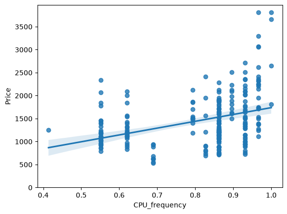

```python
# Write your code below and press Shift+Enter to execute
# CPU_frequency plot
df.describe()

sns.regplot(x=df['CPU_frequency'], y=df['Price'], data=df)
plt.ylim(0,)
```

**Click here for Solution**

```
sns.regplot(x="CPU_frequency", y="Price", data=df)
plt.ylim(0,)
```

```
(0.0, 3974.15)
```

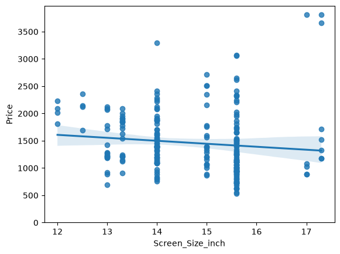

```python
# Write your code below and press Shift+Enter to execute
# Screen_Size_inch plot
sns.regplot(x=df['Screen_Size_inch'], y=df['Price'], data=df)
plt.ylim(0,)
```

**Click here for Solution**

```
sns.regplot(x="Screen_Size_inch", y="Price", data=df)
plt.ylim(0,)
```

```
(0.0, 3974.15)
```

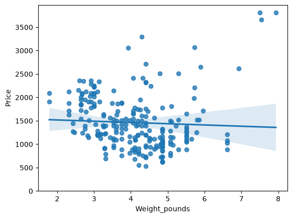

```python
# Write your code below and press Shift+Enter to execute
# Weight_pounds plot
sns.regplot(x=df['Weight_pounds'], y=df['Price'], data=df)
plt.ylim(0,)
```

**Click here for Solution**

```
sns.regplot(x="Weight_pounds", y="Price", data=df)
plt.ylim(0,)
```

```python
# Correlation values of the three attributes with Price
for param in ["CPU_frequency", "Screen_Size_inch","Weight_pounds"]:
    print("")
    print(f"Correlation of Price and {param} is ", df[param].corr(df["Price"]))
    print ("--------OR--------")
    print(f"Correlation of Price and {param} is ", df[[param,"Price"]].corr())
```

```
Correlation of Price and CPU_frequency is  0.3666655589258857
--------OR--------
Correlation of Price and CPU_frequency is                 CPU_frequency     Price
CPU_frequency       1.000000  0.366666
Price               0.366666  1.000000

Correlation of Price and Screen_Size_inch is  -0.11064420817118281
--------OR--------
Correlation of Price and Screen_Size_inch is                    Screen_Size_inch     Price
Screen_Size_inch          1.000000 -0.110644
Price                    -0.110644  1.000000

Correlation of Price and Weight_pounds is  -0.0503122583775154
--------OR--------
Correlation of Price and Weight_pounds is                 Weight_pounds     Price
Weight_pounds       1.000000 -0.050312
Price              -0.050312  1.000000
```

**Click here for Solution**

```
for param in ["CPU_frequency", "Screen_Size_inch","Weight_pounds"]:
    print(f"Correlation of Price and {param} is ", df[[param,"Price"]].corr())
```

Interpretation: "CPU_frequency" has a 36% positive correlation with the price of the laptops. The other two parameters have weak correlation with price.

### Categorical features

Generate Box plots for the different feature that hold categorical values. These features would be "Category", "GPU", "OS", "CPU_core", "RAM_GB", "Storage_GB_SSD"

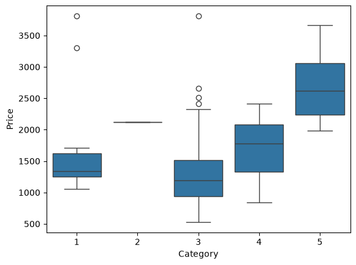

```python
# Write your code below and press Shift+Enter to execute
# Category Box plot
sns.boxplot(x=df['Category'], y=df['Price'], data=df)
```

**Click here for Solution**

```
sns.boxplot(x="Category", y="Price", data=df)
```

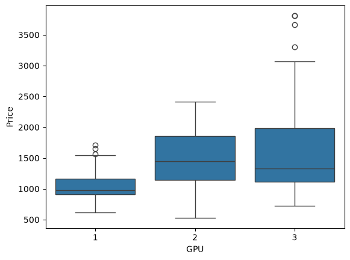

```python
# Write your code below and press Shift+Enter to execute
# GPU Box plot
sns.boxplot(x=df['GPU'], y=df['Price'], data=df)
```

**Click here for Solution**

```
sns.boxplot(x="GPU", y="Price", data=df)
```

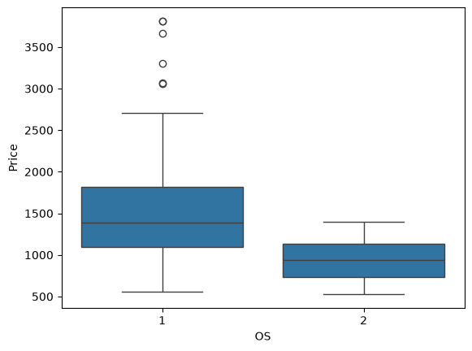

```python
# Write your code below and press Shift+Enter to execute
# OS Box plot
sns.boxplot(x=df['OS'], y=df['Price'], data=df)
```

**Click here for Solution**

```
sns.boxplot(x="OS", y="Price", data=df)
```

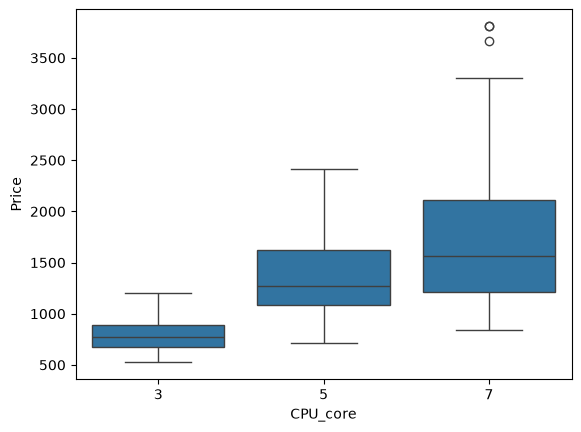

```python
# Write your code below and press Shift+Enter to execute
# CPU_core Box plot
sns.boxplot(x=df['CPU_core'], y=df['Price'], data=df)
```

**Click here for Solution**

```
sns.boxplot(x="CPU_core", y="Price", data=df)
```

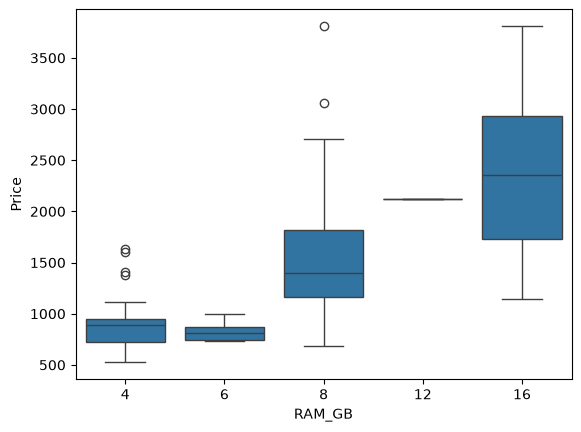

```python
# Write your code below and press Shift+Enter to execute
# RAM_GB Box plot
sns.boxplot(x=df['RAM_GB'], y=df['Price'], data=df)
```

**Click here for Solution**

```
sns.boxplot(x="RAM_GB", y="Price", data=df)
```

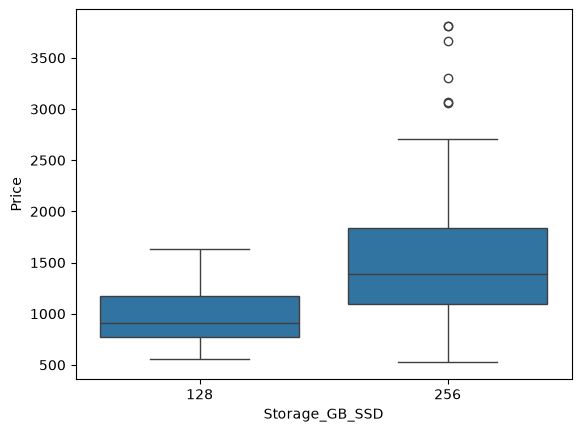

```python
# Write your code below and press Shift+Enter to execute
# Storage_GB_SSD Box plot
sns.boxplot(x=df['Storage_GB_SSD'], y=df['Price'], data=df)
```

**Click here for Solution**

```
sns.boxplot(x="Storage_GB_SSD", y="Price", data=df)
```

# Task 2 - Descriptive Statistical Analysis

Generate the statistical description of all the features being used in the data set. Include "object" data types as well.

```python
# Write your code below and press Shift+Enter to execute
print(df.describe())
print(df.describe(include=['str']))
print(df.describe(include=['object']))
```

```
       Unnamed: 0.1  Unnamed: 0    Category         GPU          OS  \
count    238.000000  238.000000  238.000000  238.000000  238.000000
mean     118.500000  118.500000    3.205882    2.151261    1.058824
std       68.848868   68.848868    0.776533    0.638282    0.235790
min        0.000000    0.000000    1.000000    1.000000    1.000000
25%       59.250000   59.250000    3.000000    2.000000    1.000000
50%      118.500000  118.500000    3.000000    2.000000    1.000000
75%      177.750000  177.750000    4.000000    3.000000    1.000000
max      237.000000  237.000000    5.000000    3.000000    2.000000

         CPU_core  Screen_Size_inch  CPU_frequency      RAM_GB  \
count  238.000000        238.000000     238.000000  238.000000
mean     5.630252         14.688655       0.813822    7.882353
std      1.241787          1.166045       0.141860    2.482603
min      3.000000         12.000000       0.413793    4.000000
25%      5.000000         14.000000       0.689655    8.000000
50%      5.000000         15.000000       0.862069    8.000000
75%      7.000000         15.600000       0.931034    8.000000
max      7.000000         17.300000       1.000000   16.000000

       Storage_GB_SSD  Weight_pounds        Price  Screen-Full_HD  \
count      238.000000     238.000000   238.000000      238.000000
mean       245.781513       4.106221  1462.344538        0.676471
std         34.765316       1.078442   574.607699        0.468809
min        128.000000       1.786050   527.000000        0.000000
25%        256.000000       3.246863  1066.500000        0.000000
50%        256.000000       4.106221  1333.000000        1.000000
75%        256.000000       4.851000  1777.000000        1.000000
max        256.000000       7.938000  3810.000000        1.000000

       Screen-IPS_panel
count        238.000000
mean           0.323529
std            0.468809
min            0.000000
25%            0.000000
50%            0.000000
75%            1.000000
max            1.000000
       Manufacturer Price-binned
count           238          238
unique           11            3
top            Dell          Low
freq             71          160
       Manufacturer Price-binned
count           238          238
unique           11            3
top            Dell          Low
freq             71          160
```

**Click here for Solution**

```
print(df.describe())
print(df.describe(include=['object']))
```

# Task 3 - GroupBy and Pivot Tables

Group the parameters "GPU", "CPU_core" and "Price" to make a pivot table and visualize this connection using the pcolor plot.

```python
# Write your code below and press Shift+Enter to execute
# Create the group
df_gp = df[['GPU','CPU_core','Price']]
df_grp = df_gp.groupby(['GPU','CPU_core'], as_index=False).mean()
print(df_grp)
```

```
   GPU  CPU_core        Price
0    1         3   769.250000
1    1         5   998.500000
2    1         7  1167.941176
3    2         3   785.076923
4    2         5  1462.197674
5    2         7  1744.621622
6    3         3   784.000000
7    3         5  1220.680000
8    3         7  1945.097561
```

**Click here for Solution**

```
df_gptest = df[['GPU','CPU_core','Price']]
grouped_test1 = df_gptest.groupby(['GPU','CPU_core'],as_index=False).mean()
print(grouped_test1)
```

```python
# Write your code below and press Shift+Enter to execute
# Create the Pivot table
grp_pivot = df_grp.pivot(index = 'GPU', columns = 'CPU_core')
print(grp_pivot)
```

```
               Price
CPU_core           3            5            7
GPU
1         769.250000   998.500000  1167.941176
2         785.076923  1462.197674  1744.621622
3         784.000000  1220.680000  1945.097561
```

**Click here for Solution**

```
grouped_pivot = grouped_test1.pivot(index='GPU',columns='CPU_core')
print(grouped_pivot)
```

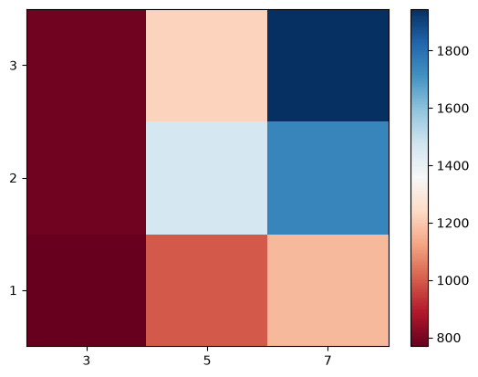

```python
# Write your code below and press Shift+Enter to execute
# Create the Plot
# plt.pcolor(grp_pivot, cmap="RdBu")
# plt.colorbar()
# plt.show()

fig, ax = plt.subplots()
im = ax.pcolor(grp_pivot, cmap='RdBu')

#label names
row_labels = grp_pivot.columns.levels[1]
col_labels = grp_pivot.index

#move ticks and labels to the center
ax.set_xticks(np.arange(grp_pivot.shape[1]) + 0.5, minor=False)
ax.set_yticks(np.arange(grp_pivot.shape[0]) + 0.5, minor=False)

#insert labels
ax.set_xticklabels(row_labels, minor=False)
ax.set_yticklabels(col_labels, minor=False)

fig.colorbar(im)
```

**Click here for Solution**

```
fig, ax = plt.subplots()
im = ax.pcolor(grouped_pivot, cmap='RdBu')

#label names
row_labels = grouped_pivot.columns.levels[1]
col_labels = grouped_pivot.index

#move ticks and labels to the center
ax.set_xticks(np.arange(grouped_pivot.shape[1]) + 0.5, minor=False)
ax.set_yticks(np.arange(grouped_pivot.shape[0]) + 0.5, minor=False)

#insert labels
ax.set_xticklabels(row_labels, minor=False)
ax.set_yticklabels(col_labels, minor=False)

fig.colorbar(im)
```

# Task 4 - Pearson Correlation and p-values

Use the `scipy.stats.pearsonr()` function to evaluate the Pearson Coefficient and the p-values for each parameter tested above. This will help you determine the parameters most likely to have a strong effect on the price of the laptops.

```python
# Write your code below and press Shift+Enter to execute
for x in ['RAM_GB','CPU_frequency','Storage_GB_SSD','Screen_Size_inch','Weight_pounds','CPU_core','OS','GPU','Category']:
    pear_coef, p_value = stats.pearsonr(df[x],df['Price'])
    print("")
    print (f"Pearson Coefficient for {x} against Price is: {pear_coef} and P-Value is {p_value}")
```

```
Pearson Coefficient for RAM_GB against Price is: 0.5492972971857844 and P-Value is 3.681560628842865e-20

Pearson Coefficient for CPU_frequency against Price is: 0.36666555892588604 and P-Value is 5.50246335071342e-09

Pearson Coefficient for Storage_GB_SSD against Price is: 0.243420755218103 and P-Value is 0.00014898923191724168

Pearson Coefficient for Screen_Size_inch against Price is: -0.11064420817118266 and P-Value is 0.08853397846830696

Pearson Coefficient for Weight_pounds against Price is: -0.05031225837751544 and P-Value is 0.43976938534338955

Pearson Coefficient for CPU_core against Price is: 0.4593977773355115 and P-Value is 7.912950127009037e-14

Pearson Coefficient for OS against Price is: -0.22172980114827384 and P-Value is 0.0005696642559246716

Pearson Coefficient for GPU against Price is: 0.2882981988881427 and P-Value is 6.166949698364507e-06

Pearson Coefficient for Category against Price is: 0.28624275581264125 and P-Value is 7.2256962358067295e-06
```

**Click here for Solution**

```
for param in ['RAM_GB','CPU_frequency','Storage_GB_SSD','Screen_Size_inch','Weight_pounds','CPU_core','OS','GPU','Category']:
    pearson_coef, p_value = stats.pearsonr(df[param], df['Price'])
    print(param)
    print("The Pearson Correlation Coefficient for ",param," is", pearson_coef, " with a P-value of P =", p_value)
```

# Congratulations! You have completed the lab

## Authors

[Abhishek Gagneja](https://www.coursera.org/instructor/~129186572)

[Vicky Kuo](https://author.skills.network/instructors/vicky_kuo)

Copyright © 2023 IBM Corporation. All rights reserved.